# Data624_Hw6

### c) Write your own code to generate data from an MA(1) model with θ1=0.6 and σ2=1.

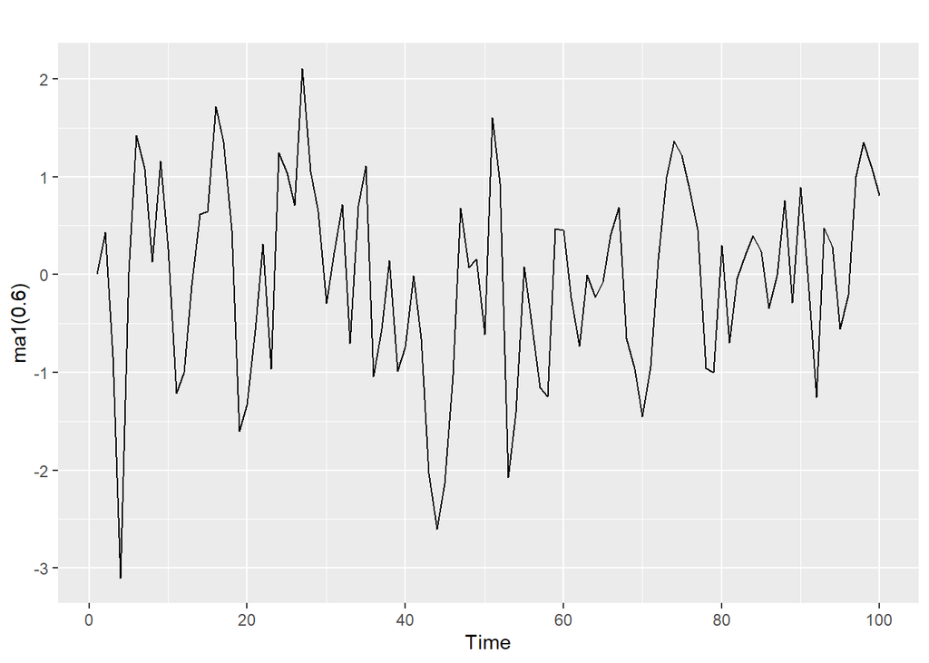

```r
ma1 <- function(theta){
  y <- ts(numeric(100))
  e <- rnorm(100)
  for(i in 2:100)
    y[i] <- theta*e[i-1] + e[i]
  return(y)
}
autoplot(ma1(0.6))
```

### d) d. Produce a time plot for the series. How does the plot change as you change θ1?

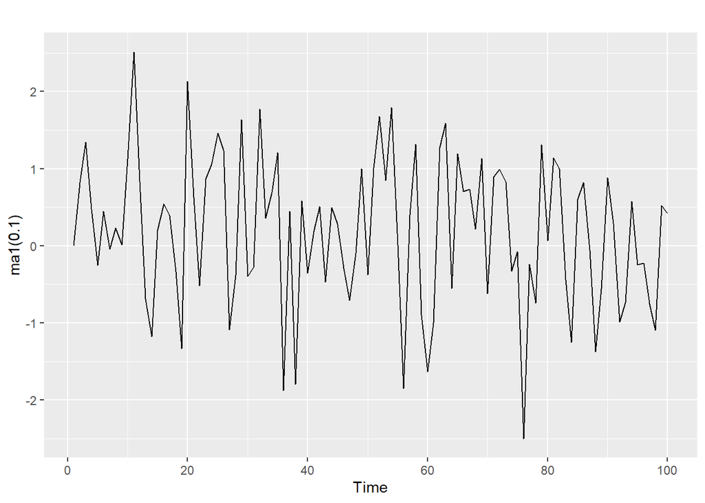

```r
autoplot(ma1(0.1))
```

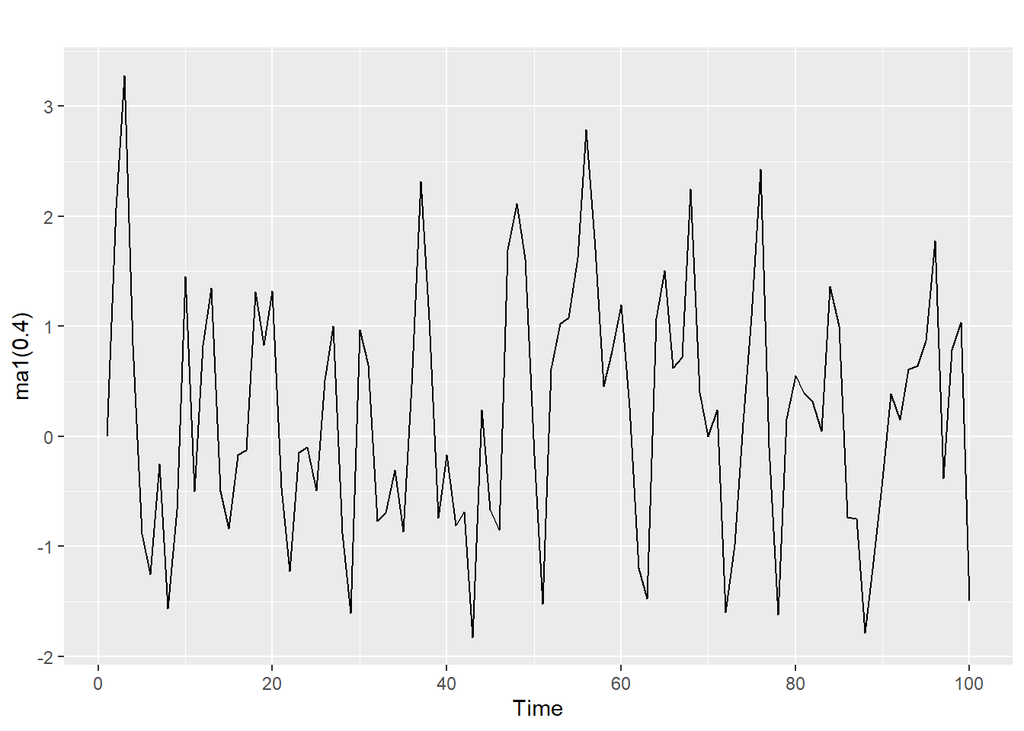

```r
autoplot(ma1(0.4))
```

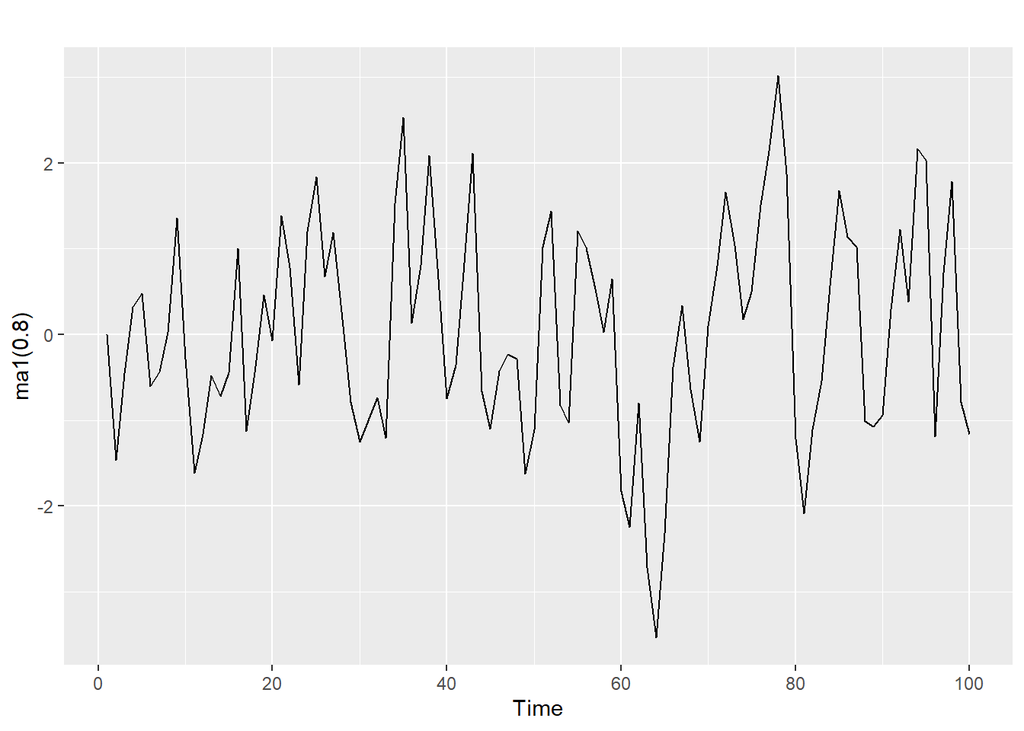

```r
autoplot(ma1(0.8))
```

### e) Generate data from an ARMA(1,1) model with ϕ1=0.6, θ1=0.6 and σ2=1

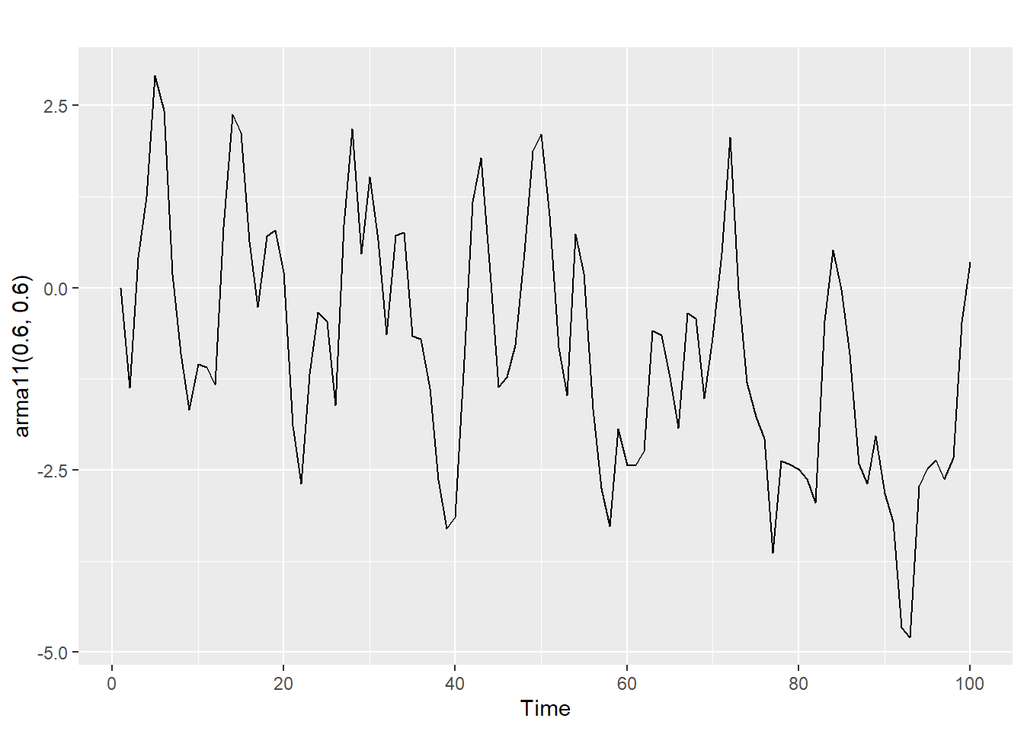

```r
arma11 <- function(phi, theta, n=100){
  y <- ts(numeric(100))
  e <- rnorm(100)
  for(i in 2:100)
    y[i] <- phi*y[i-1] + theta*e[i-1] + e[i]
  return(y)
}
autoplot(arma11(0.6, 0.6))
```

### f) Generate data from an AR(2) model with θ1=−0.8, θ2=0.3, and σ2=1. (Note that these parameters will give a non-stationary series)

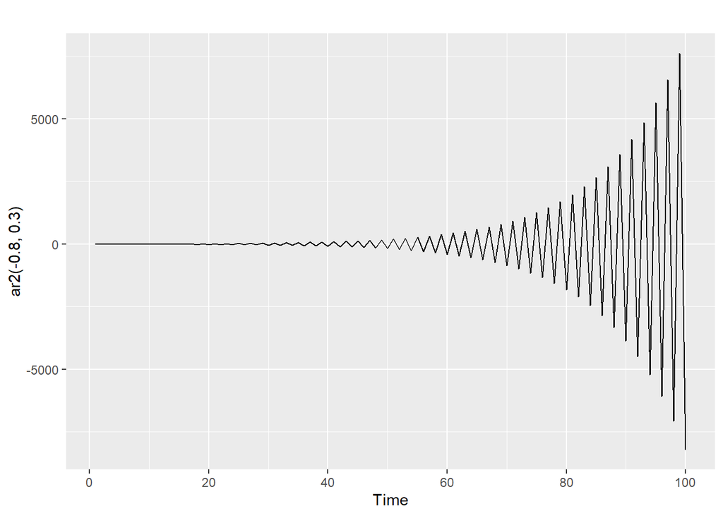

```r
ar2 <- function(phi1, phi2, n=100){
  y <- ts(numeric(100))
  e <- rnorm(100)
  for(i in 3:100)
    y[i] <- phi1*y[i-1] + phi2*y[i-2] + e[i]
  return(y)
}
autoplot(ar2(-0.8,0.3))
```

### g) Graph the latter two series and compare them.

#### We have already plotted them in the above questions and we can observe that AR(2) series has increase in variance over time.

### 8.7 Consider wmurders, the number of women murdered each year (per 100,000 standard population) in the United States.